# Лабораторная работа №1

Простые модели компьютерной сети

Шубнякова Дарья НКНбд-01-22

1132226452@pfur.ru

Российский университет дружбы народов

# Вводная часть

## Цели и задачи

Приобретение навыков моделирования сетей передачи данных с помощью средства имитационного моделирования NS-2, а также анализ полученных результатов моделирования.

# Основная часть

## Выполнение лабораторной работы

Создаем директорию mip для работы с NS и создаем шаблон для дальнейшего выполнения лабораторной.

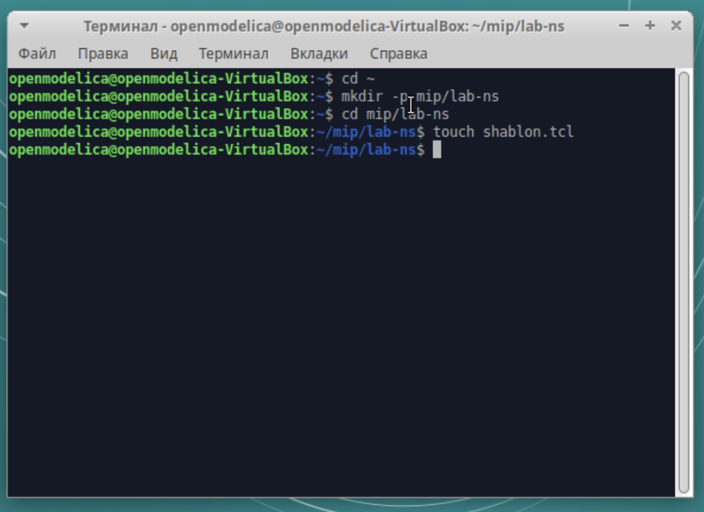

Создание директории

## Берем шаблон из задания и у нас запускается пустой симулятор.

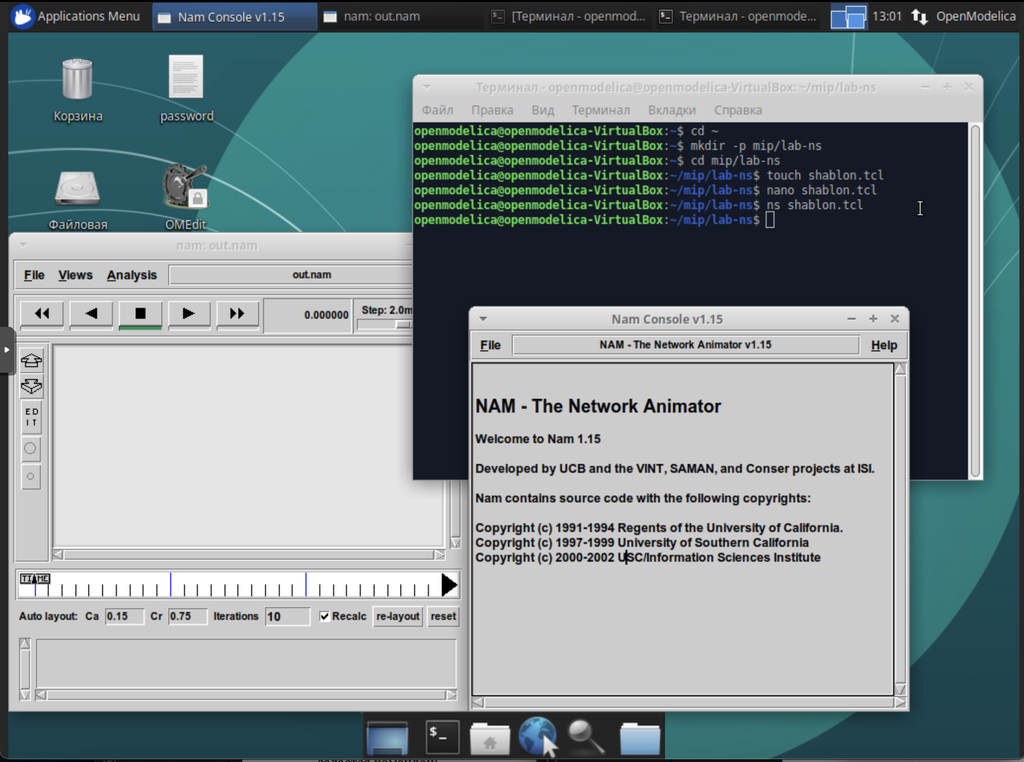

Пустой симулятор

## Работаем с первым примером из задания, смотрим, что будет происходить.

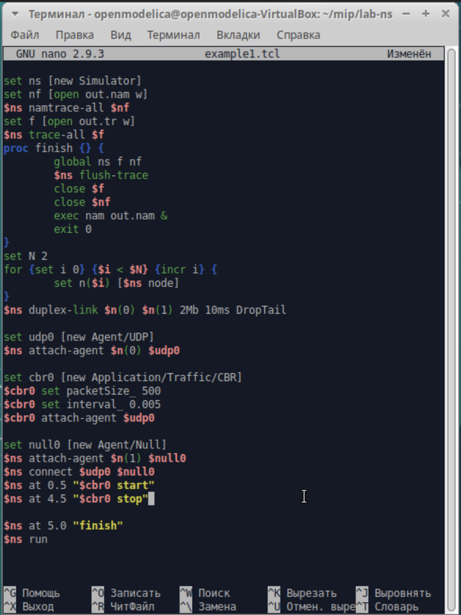

Первый пример

## У нас появилась сеть из двух узлов и идущие пакеты из 0 в 1.

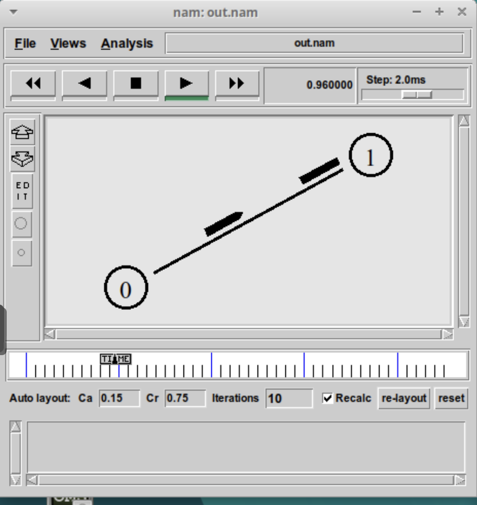

Сеть из двух узлов

## Берем код для второго примера и вставляем его, параллельно читая все комментарии к тому, что делаем.

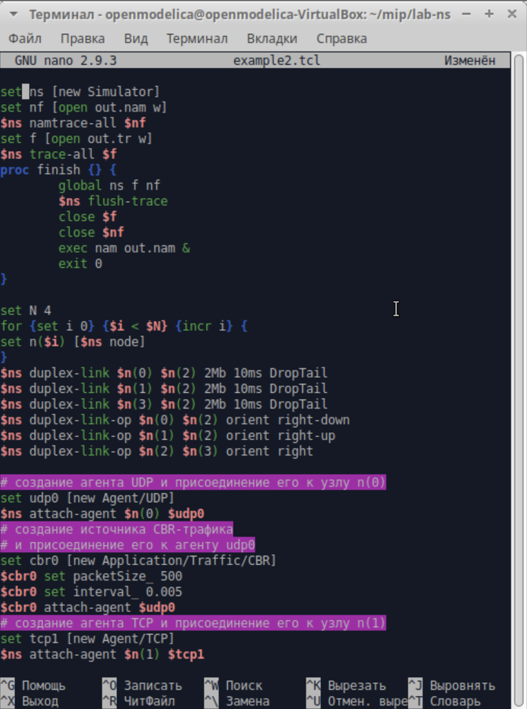

Код второго примера

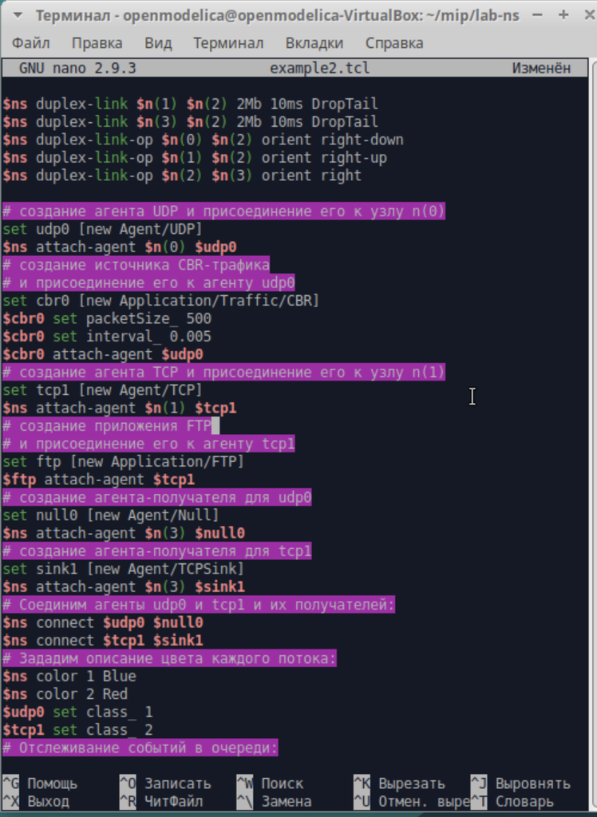

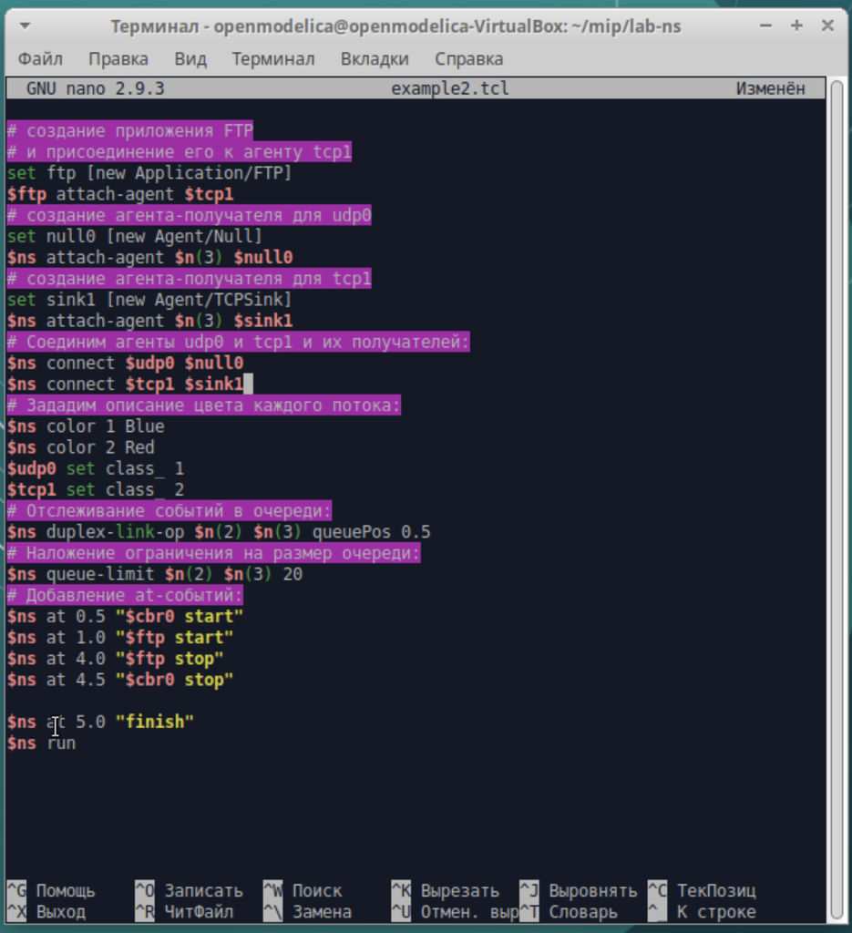

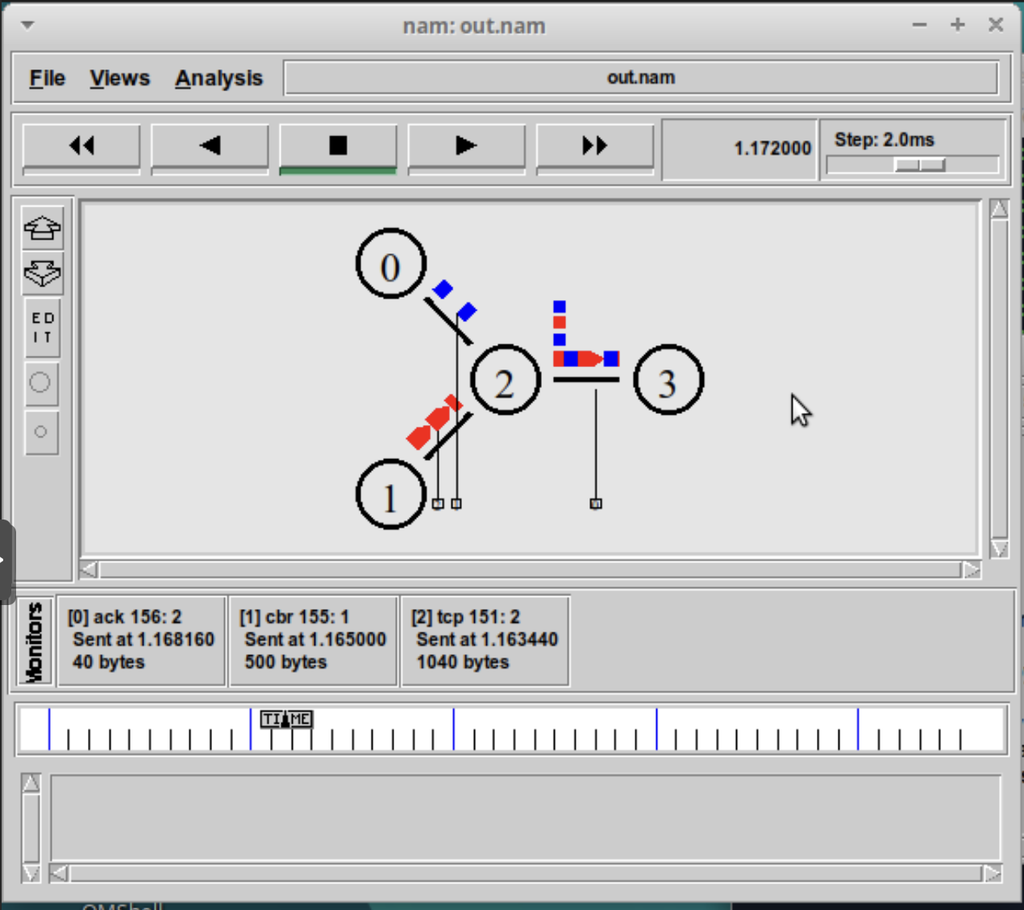

Перегрузка соединения

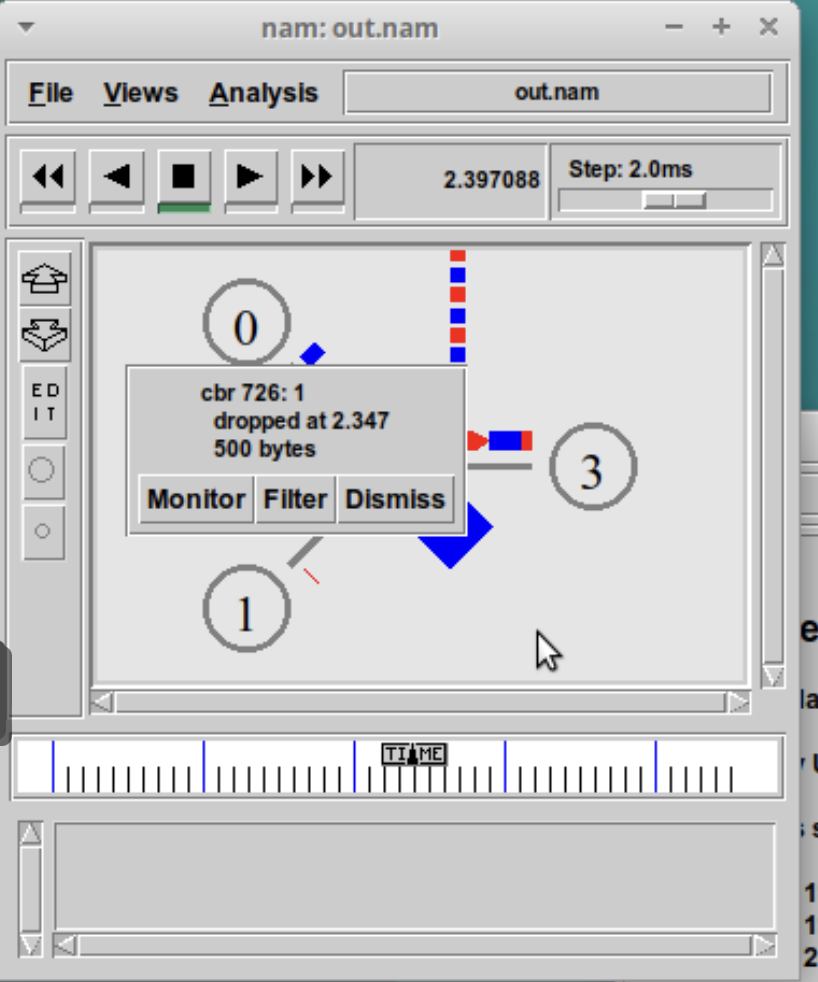

Потеря пакетов

## Далее мы строим третий пример с кольцевой топологией сети. Вводим код, данный в задании.

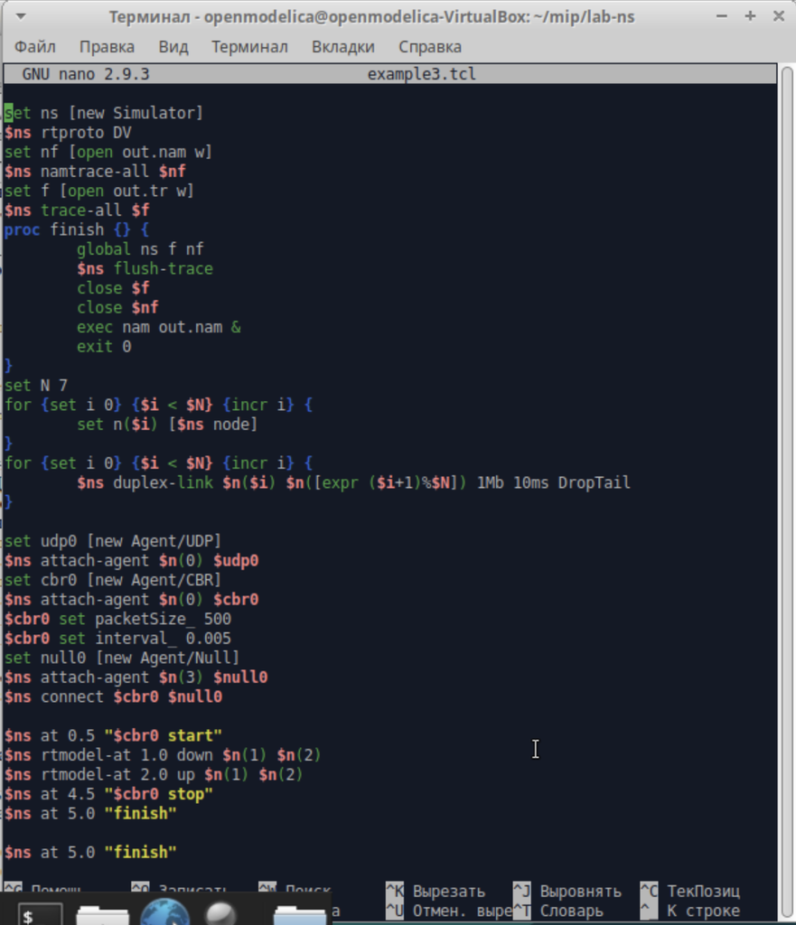

Код третьего примера

## Видим, как у нас идут пакеты из 0 в 3.

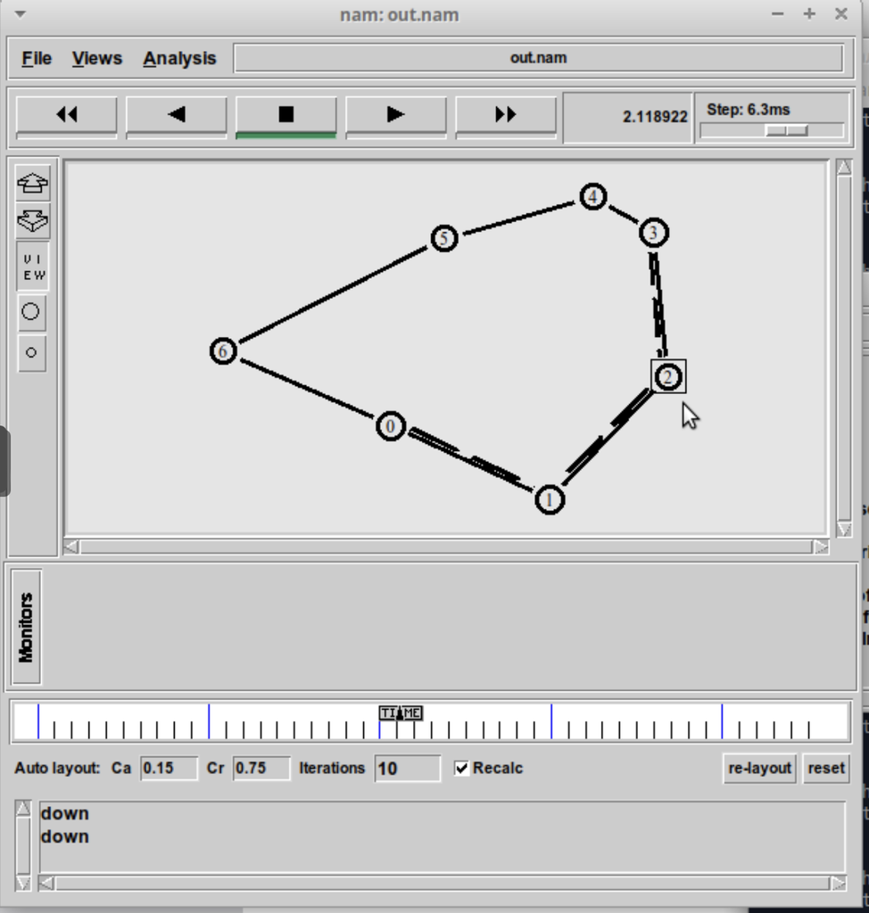

Передача пакетов

## Во время разрыва соединения у нас происходит утечка пакетов.

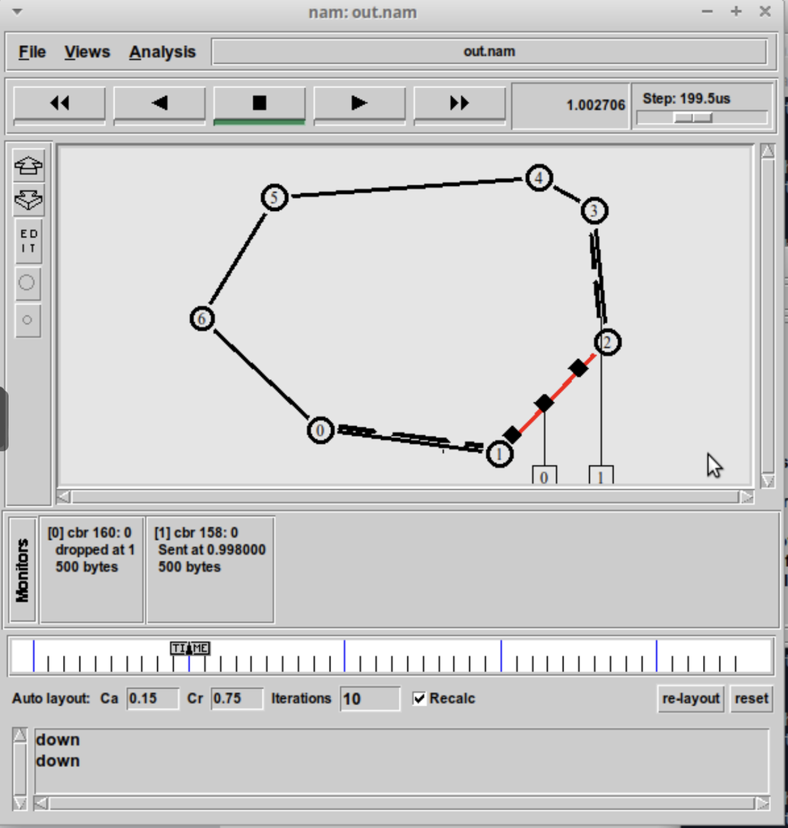

Разрыв соединения

## И наши пакеты начинают двигаться по более длинному пути.

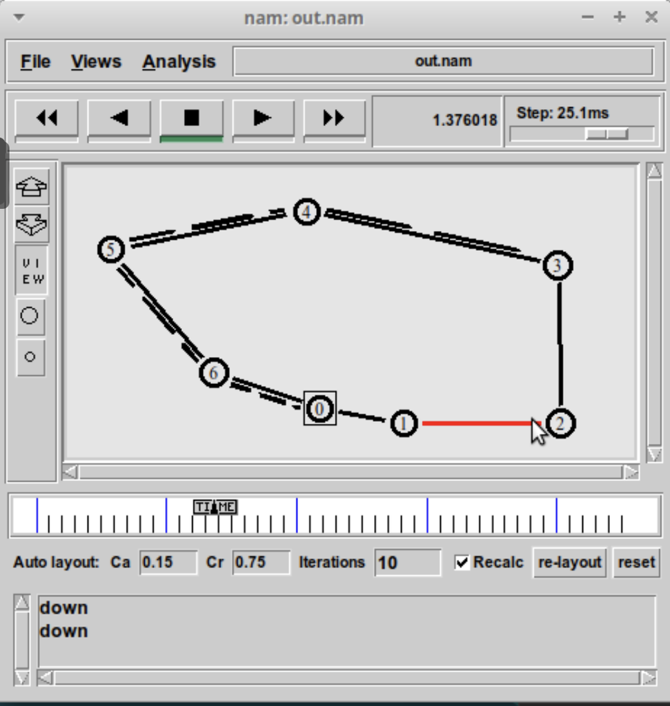

Альтернативный путь

## После восстановления сети пакеты снова движутся по короткому пути.

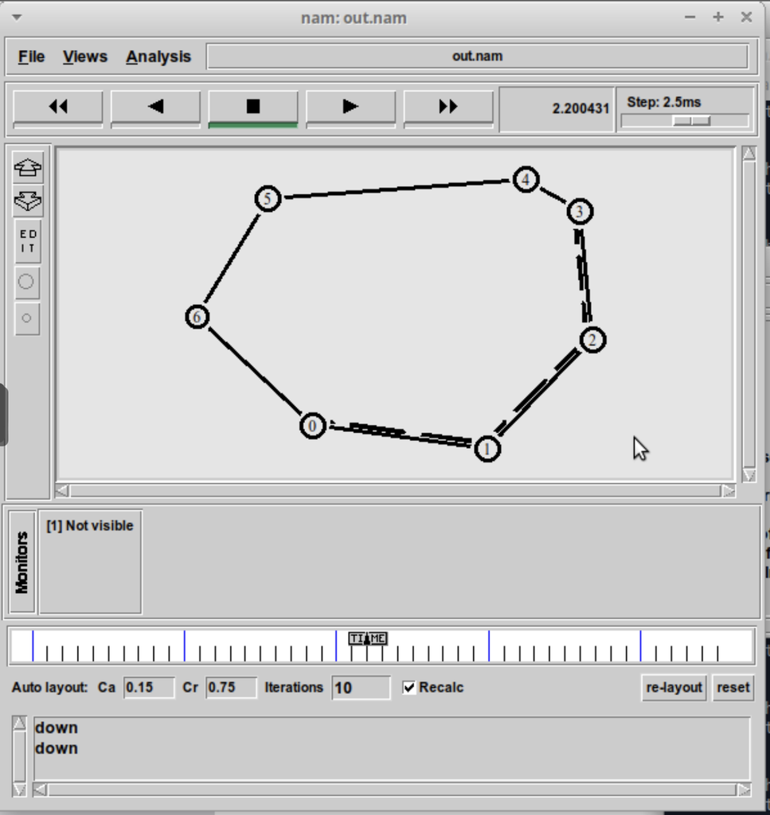

Восстановление сети

## Пишем код для упражнения. Его можно найти в моем репозитории на GitHub dishubnyakova/simmod в документах к первой лабораторной работе.

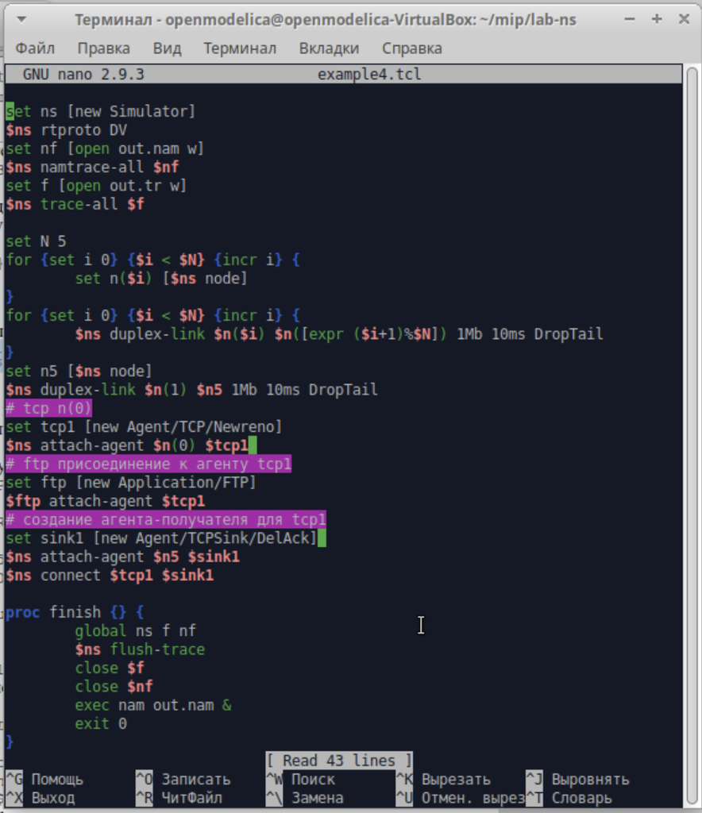

Код упражнения

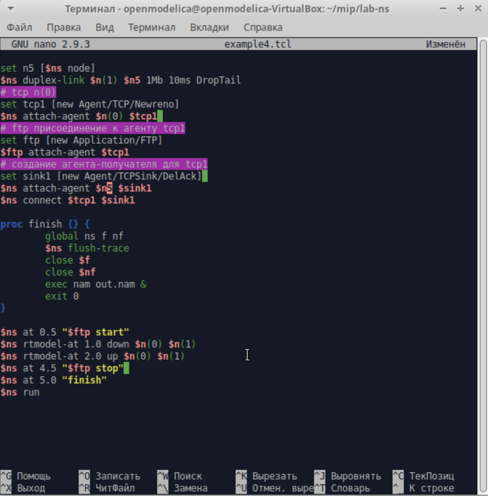

Код упражнения

## Тут все как с примером с кольцевой топологией сети кроме того, что нам пришлось подключить узел 5. Видим, как у нас идут пакеты.

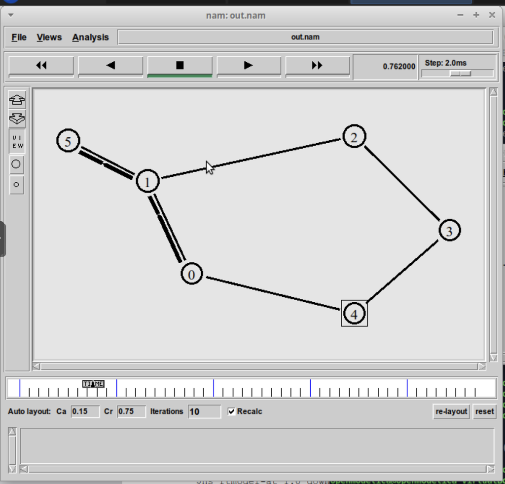

Подключение узла 5

## Потом сеть разрывается, мы теряем пакеты.

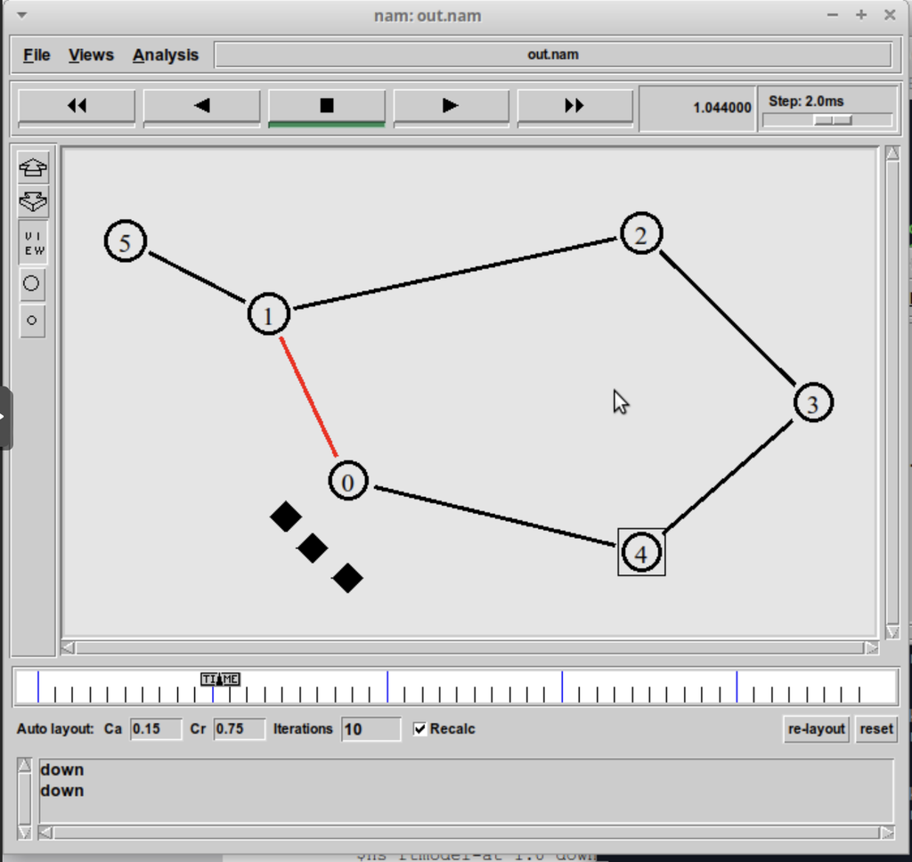

Разрыв сети

## Они находят себе новый путь.

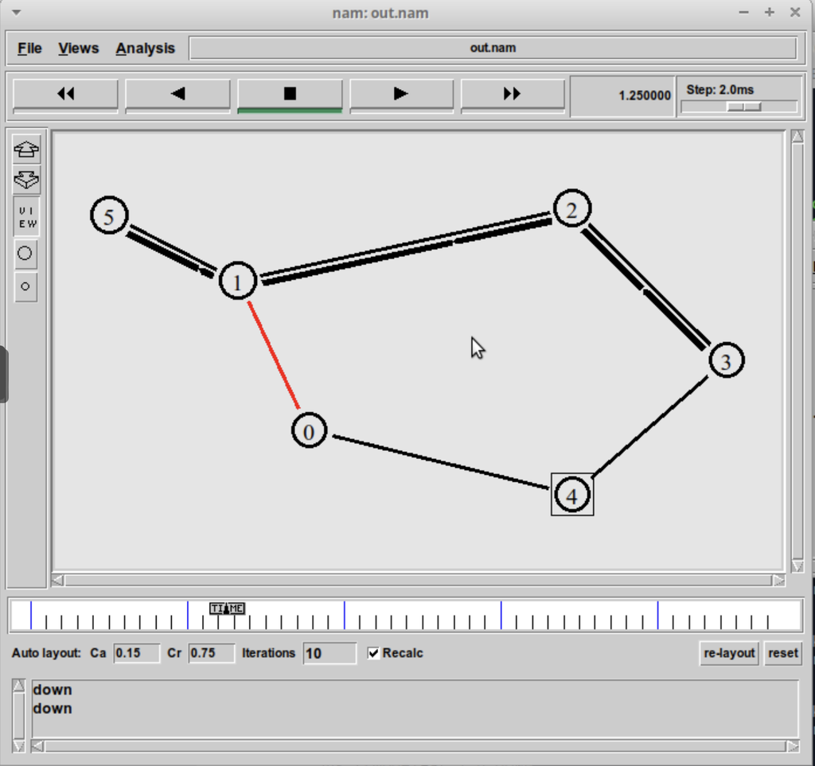

Новый путь

## А после восстановления сети, восстанавливается и передача пакетов.

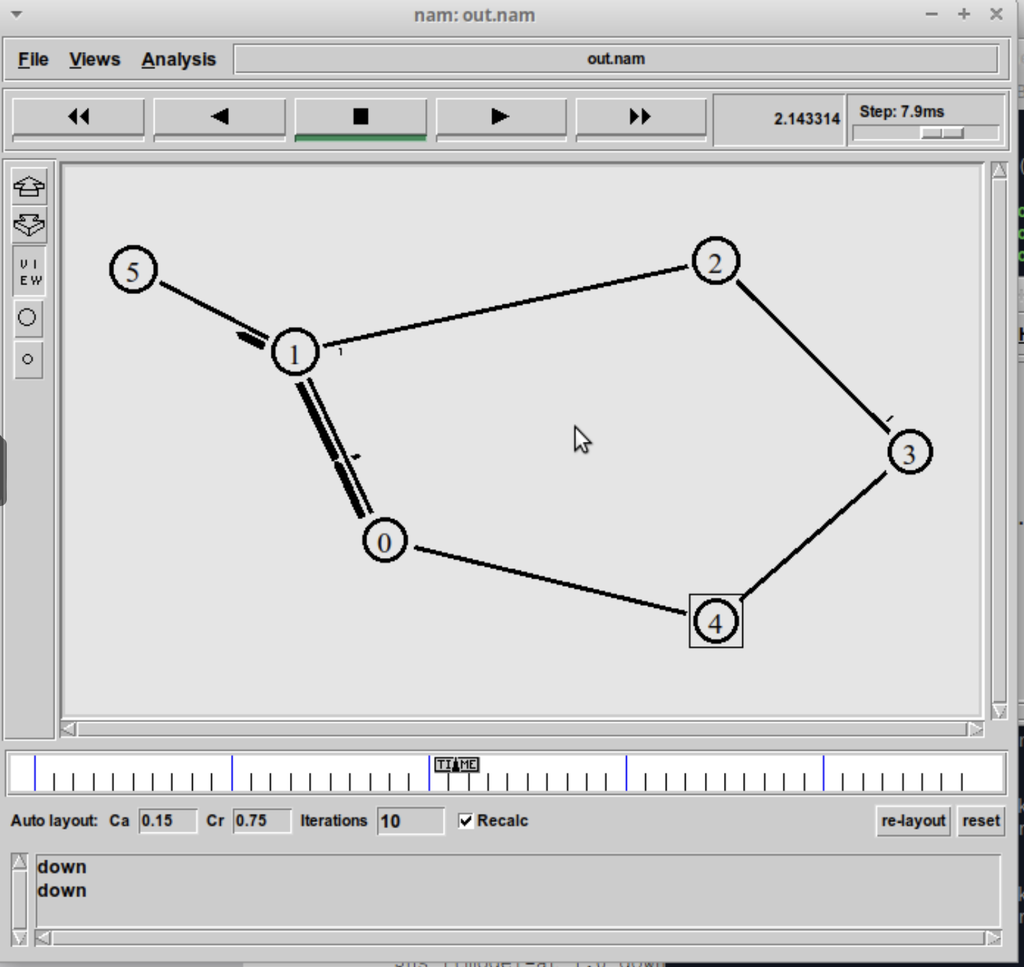

Восстановление передачи

# Результаты

Мы научились делать три вида моделей, из которых потом создали свою собственную из упражнения, где:

- Передача данных осуществляется от узла n(0) до узла n(5) по кратчайшему пути в течение 5 секунд модельного времени;
- Передача данных должна идти по протоколу TCP (тип Newreno), на принимающей стороне используется TCPSink-объект типа DelAck; поверх TCP работает протокол FTP с 0,5 до 4,5 секунд модельного времени;
- С 1 по 2 секунду модельного времени происходит разрыв соединения между узлами n(0) и n(1);
- При разрыве соединения маршрут передачи данных должен измениться на резервный, после восстановления соединения пакеты снова должны пойти по кратчайшему пути.